# Regression Analysis

### Distribution of dataset

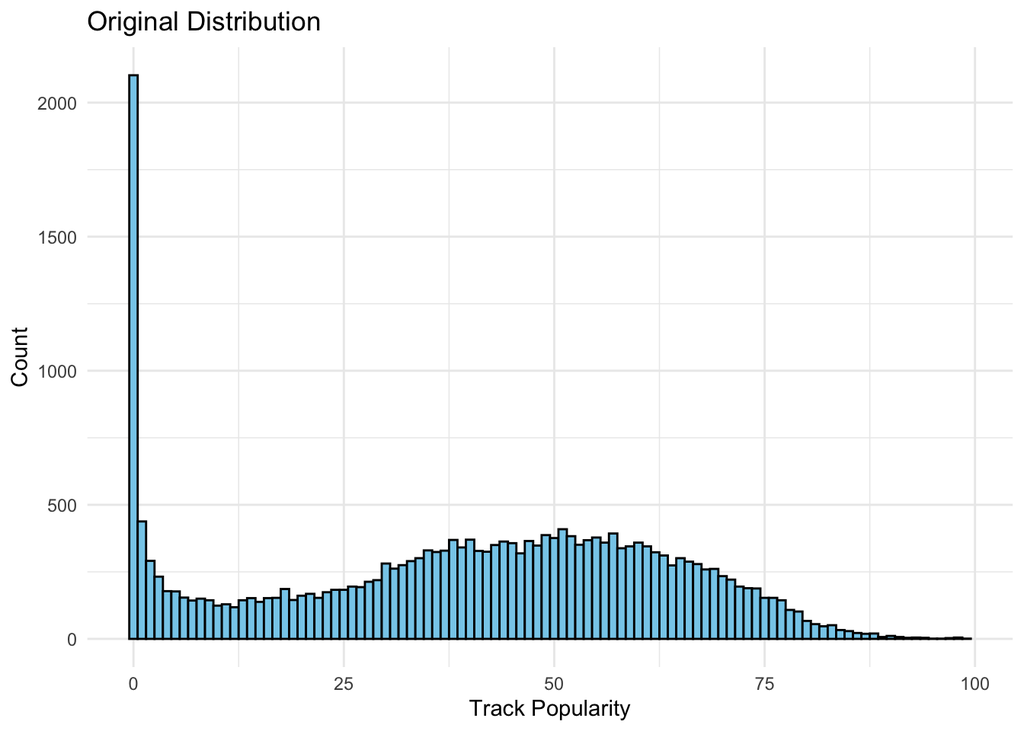

```r
p1 <- ggplot(train_data, aes(x = track_popularity)) +
  geom_histogram(binwidth = 1, fill = "skyblue", color = "black") +
  labs(title = "Original Distribution", x = "Track Popularity", y = "Count") +
  theme_minimal()
p1
```

The distribution of track popularity shows:

- **High Frequency at Zero Popularity**: A significant number of songs have a popularity score of zero, representing tracks that are rarely or never played, newly added songs with no audience, or niche tracks with limited reach.
- **Broad Range for Other Popularity Scores**: Beyond zero, the distribution is relatively uniform, with a slight bell-shaped curve centered around the middle of the popularity scale (around 50). This suggests many songs have moderate popularity, while fewer achieve very high scores.
- **Tapering at Higher Scores**: The declining bars for scores above 70 indicate that only a small proportion of tracks reach the highest levels of popularity.

This distribution highlights the need for possible transformations to address the over representation at zero.